# Project-6101

Sunny

2024-11-29

## 1.Data ETL

```r
data_raw <- read.csv("C:/Users/qluo/Box/DATS 6101/Group-Project2/Combined_SDOH_2019_2020.csv")
```

```r
col_indices <- c('COUNTYFIPS','YEAR','ACS_PCT_FEMALE','ACS_PCT_AGE_15_17',
                 'ACS_PCT_AGE_18_29','ACS_PCT_AGE_30_44',
                 'ACS_PCT_AIAN_NONHISP','ACS_PCT_ASIAN_NONHISP',
                 'ACS_PCT_BLACK_NONHISP',
                 'ACS_PCT_HISPANIC','ACS_PCT_NHPI_NONHISP','ACS_PCT_OTHER_NONHISP',
                 'ACS_PCT_NOT_LABOR','ACS_MEDIAN_HH_INC','ACS_PCT_HEALTH_INC_BELOW137',
                 'AHRF_UNEMPLOYED_RATE','AHRF_NURSE_MIDWIVES_RATE','CDCW_MATERNAL_DTH_RATE',
                 'POS_MEDIAN_DIST_OBSTETRICS','POS_FQHC_RATE',
                 'POS_HOSP_OBSTETRIC_RATE','POS_HOSP_MEDSURG_ICU_RATE','POS_HOSP_ED_RATE','POS_PCT_HOSP_GOV')

subset_data <- data_raw[,col_indices]
colnames(subset_data) <- c('countyfips','YEAR','Percent_femal_pop',"Percent_pop_15_17","Percent_pop_18_29","Percent_pop_30_44",
                           'Percent_pop_American_Indian_and_Alaska_Native','Percent_pop_Asian',
                           'Percent_pop_Black_and_African_American','Percent_pop_Hispanic',
                           'Percent_pop_Native_Hawaiian_and_Pacific_Islander','Percent_pop_other_race',
                           "Percent_pop_not_in_labor_force_16",'Median_household_income',
                           'Percent_pop_under_1.37_of_poverty_threshold',
                           "Unemployment_rate_per_100_population_16",
                           'Number_of_midwives','Maternal_mortality_rate',
                           'Median_distance_to_nearest_obstetrics_department','Numer_of_health_centers',
                           'Number_of_hospitals_with_obstetric','Number_of_hospitals_with_ICU',
                           'Number_of_hospitals_with_emergency_department','Percent_government_hospitals')
```

We can divide the variables into different categories, making them clear when showing the independent variables.

## 2. Outcome Imputation

```r
print(paste0("Maternal_mortality_rate is missing in ", round(sum(is.na(subset_data$Maternal_mortality_rate))/nrow(subset_data)*100,2),"% of observations."))
```

```
## [1] "Maternal_mortality_rate is missing in 94.01% of observations."
```

```r
print(paste0("Maternal_mortality_rate is 0 in ", round(sum(subset_data$Maternal_mortality_rate==0, na.rm=T)/nrow(subset_data)*100,2),"% of observations."))
```

```
## [1] "Maternal_mortality_rate is 0 in 0% of observations."
```

The highly missing nature of outcome variable *Maternal_mortality_rate* is unexpected. Also, there was no 0 maternal mortality reported in any county. We believe that ARHQ SDOH database is constructed using CDC Wonder’s default output settings which suppresses deaths between 1-9 and does not output true zeros.

We used the following procedure to impute the maternal mortality counts and collaterally the maternal mortality rates. 1. Downloaded the multiple cause maternal mortality for year 2019 and 2020 from CDC Wonder for both state and county level. We made sure that the numbers for non-missing counties matches the record in SDOH database. 2. Downloaded the all cause mortality and underlying cause that is not maternal causes at county level from CDC Wonder. By subtracting the two, we back out the underlying cause mortality due to maternal causes. 3. We used the underlying cause of mortality to distribute the gap between reported county level total mortality and state level total mortality, making sure that states with suppressed mortality has a mortality counts from the larger between underlying cause mortality and 1 to 9 and the counties with true zero maternal mortality stays true zero. 4. We replace the imputed maternal mortality rate in the original dataframe.

### 2.1 CDC Wonder Data Processing and Imputing

```r
library(readxl)
library(dplyr)
library(stringr)

# Function to clean County and State columns
clean_column <- function(column) {
  column %>%
    str_replace_all("\\*|‡|†| ", "") %>%
    str_trim()
}

# Function to handle iterative adjustments for Stage 3
adjust_imputation <- function(data) {
  # Initialize loop variables
  gap_mean <- mean(data$gap3, na.rm = TRUE)
  counter <- 0

  while (gap_mean != 0 & counter < 20) {
    data <- data %>%
      mutate(
        # Step 1: Identify eligible rows for imputation
        impute_elig = ifelse(
          !is.na(all_deaths_under) & is.na(maternal_multi) & between(dist3, 1, 9),
          1,
          0
        )
      ) %>%
      group_by(state_fips) %>%
      mutate(
        # Step 2: Calculate dist3_factor
        dist3_factor = ifelse(
          impute_elig == 1,
          sum(ifelse(impute_elig == 1, impute_weight, NA), na.rm = TRUE),
          NA
        )
      ) %>%
      ungroup() %>%
      mutate(
        # Step 3: Update dist3
        dist3 = ifelse(
          impute_elig == 1,
          ifelse(
            dist3 + (gap3 / dist3_factor * impute_weight) <= 9,
            dist3 + (gap3 / dist3_factor * impute_weight),
            9
          ),
          dist3
        )
      ) %>%
      group_by(state_fips) %>%
      mutate(
        # Step 4: Calculate reported_total3
        reported_total3 = sum(dist3, na.rm = TRUE)
      ) %>%
      ungroup() %>%
      mutate(
        # Step 5: Update gap3
        gap3 = maternal_multi_st - reported_total3
      )

    # Update loop variables
    gap_mean <- mean(data$gap3, na.rm = TRUE)
    counter <- counter + 1
  }

  return(data)
}

# Process Impute_2019
impute_2019 <- read_excel("MaternalMortality-addtl-data.xlsx", sheet = "Impute_2019") %>%
  mutate(
    population = as.numeric(population),
    County = clean_column(County)
  ) %>%
  filter(!is.na(County)) %>%
  mutate(
    cnty_fips = str_sub(str_sub(County, -7), 2, 6),
    state_fips = str_sub(cnty_fips, 1, 2)
  )

# Process State_2019
state_2019 <- read_excel("MaternalMortality-addtl-data.xlsx", sheet = "State_2019") %>%
  rename(maternal_multi_st = maternal_multi) %>%
  mutate(
    state = clean_column(state),
    state_fips = str_sub(str_sub(state, -3), 1, 2)
  ) %>%
  filter(!is.na(state))

# Merge and process 2019 data
merged_2019 <- left_join(impute_2019, state_2019, by = "state_fips") %>%
  group_by(state_fips) %>%
  mutate(
    # Stage 1: Calculate reported_total1 and gap1
    reported_total1 = sum(maternal_multi, na.rm = TRUE),
    gap1 = maternal_multi_st - reported_total1,
    # Stage 2: Calculate dist2, reported_total2, and gap2
    dist2 = ifelse(
      !is.na(all_deaths_under) & is.na(maternal_multi),
      pmax(maternal_under, 1),
      maternal_multi
    ),
    reported_total2 = sum(dist2, na.rm = TRUE),
    gap2 = maternal_multi_st - reported_total2
  ) %>%
  ungroup() %>%
  mutate(
    # Stage 3: Initialize dist3, gap3, and impute_weight
    dist3 = dist2,
    gap3 = gap2,
    impute_weight = maternal_under + 1
  )

# Apply Stage 3 logic to adjust dist3
merged_2019 <- adjust_imputation(merged_2019) %>%
  mutate(
    maternal_mortality_rate = dist3 / population * 100000,
    year = 2019
  ) %>%
  select(County, cnty_fips, maternal_mortality_rate, year)

# Process Impute_2020
impute_2020 <- read_excel("MaternalMortality-addtl-data.xlsx", sheet = "Impute_2020") %>%
  mutate(
    population = as.numeric(population),
    County = clean_column(County)
  ) %>%
  filter(!is.na(County)) %>%
  mutate(
    cnty_fips = str_sub(str_sub(County, -7), 2, 6),
    state_fips = str_sub(cnty_fips, 1, 2)
  )

# Process State_2020
state_2020 <- read_excel("MaternalMortality-addtl-data.xlsx", sheet = "State_2020") %>%
  rename(maternal_multi_st = maternal_multi) %>%
  mutate(
    state = clean_column(state),
    state_fips = str_sub(str_sub(state, -3), 1, 2)
  ) %>%
  filter(!is.na(state))

# Merge and process 2020 data
merged_2020 <- left_join(impute_2020, state_2020, by = "state_fips") %>%
  group_by(state_fips) %>%
  mutate(
    # Stage 1: Calculate reported_total1 and gap1
    reported_total1 = sum(maternal_multi, na.rm = TRUE),
    gap1 = maternal_multi_st - reported_total1,
    # Stage 2: Calculate dist2, reported_total2, and gap2
    dist2 = ifelse(
      !is.na(all_deaths_under) & is.na(maternal_multi),
      pmax(maternal_under, 1),
      maternal_multi
    ),
    reported_total2 = sum(dist2, na.rm = TRUE),
    gap2 = maternal_multi_st - reported_total2
  ) %>%
  ungroup() %>%
  mutate(
    # Stage 3: Initialize dist3, gap3, and impute_weight
    dist3 = dist2,
    gap3 = gap2,
    impute_weight = maternal_under + 1
  )

# Apply Stage 3 logic to adjust dist3
merged_2020 <- adjust_imputation(merged_2020) %>%
  mutate(
    maternal_mortality_rate = dist3 / population * 100000,
    year = 2020
  ) %>%
  select(County, cnty_fips, maternal_mortality_rate, year)

# Combine 2019 and 2020 data
combined <- bind_rows(merged_2019, merged_2020)

# View final combined data
print(head(combined))
```

```
## # A tibble: 6 × 4
##   County                     cnty_fips maternal_mortality_rate  year
##   <chr>                      <chr>                       <dbl> <dbl>
## 1 Autauga County, AL (01001) 01001                       0      2019
## 2 Baldwin County, AL (01003) 01003                       0.394  2019
## 3 Barbour County, AL (01005) 01005                       2.28   2019
## 4 Bibb County, AL (01007)    01007                       1.15   2019
## 5 Blount County, AL (01009)  01009                       1.45   2019
## 6 Bullock County, AL (01011) 01011                       5.62   2019
```

### 2.2 Merge Imputed Outcome to SDOH Data

```r
# Ensure COUNTYFIPS in subset_data is formatted as a 5-digit string
subset_data <- subset_data %>%
  mutate(
    countyfips = sprintf("%05d", as.integer(countyfips))
  )

# Join subset_data with combined on YEAR and COUNTYFIPS/cnty_fips
merged_data <- subset_data %>%
  left_join(
    combined,
    by = c("YEAR" = "year", "countyfips" = "cnty_fips")
  )

# Fill missing Maternal_mortality_rates in subset_data with values from combined
subset_data <- merged_data %>%
  mutate(
    Maternal_mortality_rate = ifelse(
      is.na(Maternal_mortality_rate),
      maternal_mortality_rate,
      Maternal_mortality_rate
    )
  ) %>%
  select(-maternal_mortality_rate,-countyfips, -YEAR,-County) # Remove unnecessary columns if desired
# View the updated subset_data
print(head(subset_data))
```

```
##   Percent_femal_pop Percent_pop_15_17 Percent_pop_18_29 Percent_pop_30_44
## 1             51.37              4.65             15.19             19.43
## 2             51.37              3.87             12.99             17.67
## 3             47.08              3.60             15.44             19.14
## 4             45.98              4.29             14.59             20.44
## 5             50.60              4.04             13.88             18.38
## 6             45.64              3.84             16.57             19.28
##   Percent_pop_American_Indian_and_Alaska_Native Percent_pop_Asian
## 1                                          0.25              1.03
## 2                                          0.65              0.92
## 3                                          0.29              0.48
## 4                                          0.13              0.12
## 5                                          0.07              0.37
## 6                                          0.00              0.49
##   Percent_pop_Black_and_African_American Percent_pop_Hispanic
```

[output cut: 62 more lines]

### 2.3 KNN Imputation of Other Variables

```r
if (!require("VIM")) install.packages("VIM")
library(VIM)



outcome_column <- subset_data$Maternal_mortality_rate
subset_data_no_outcome <- subset_data %>%
  select(-Maternal_mortality_rate)

# Perform KNN imputation on the predictors
subset_data_imputed <- kNN(subset_data_no_outcome, k = 5, imp_var = FALSE)

# Add the outcome column back
subset_data_imputed$outcome <- outcome_column

# Apply KNN imputation
subset_data_imputed <- kNN(subset_data, k = 5, imp_var = FALSE)



# View the first few rows of the imputed dataframe
head(subset_data_imputed)
```

```
##   Percent_femal_pop Percent_pop_15_17 Percent_pop_18_29 Percent_pop_30_44
## 1             51.37              4.65             15.19             19.43
## 2             51.37              3.87             12.99             17.67
## 3             47.08              3.60             15.44             19.14
## 4             45.98              4.29             14.59             20.44
## 5             50.60              4.04             13.88             18.38
## 6             45.64              3.84             16.57             19.28
##   Percent_pop_American_Indian_and_Alaska_Native Percent_pop_Asian
## 1                                          0.25              1.03
## 2                                          0.65              0.92
## 3                                          0.29              0.48
## 4                                          0.13              0.12
## 5                                          0.07              0.37
## 6                                          0.00              0.49
##   Percent_pop_Black_and_African_American Percent_pop_Hispanic
```

[output cut: 62 more lines]

```r
subset_data=subset_data_imputed
```

## 3. Descriptive Analysis of Maternal Mortality Rates

It shows non-normal distribution.

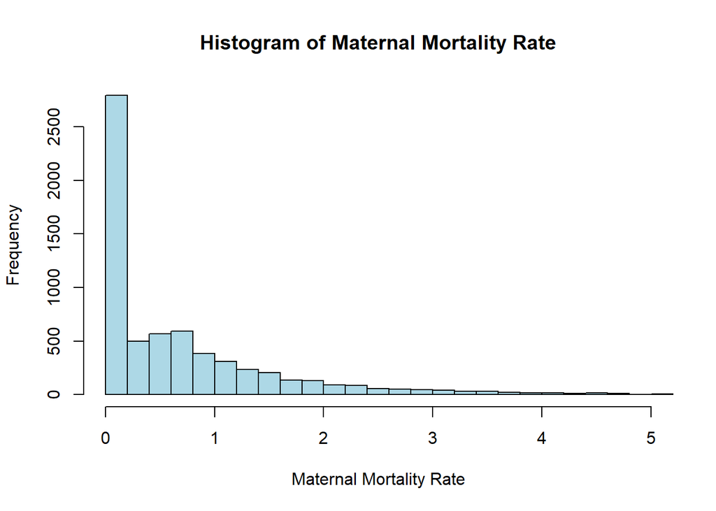

```r
hist(subset_data$Maternal_mortality_rate,
     xlim = c(0, 5),  # Adjust the x-axis to a smaller range
     breaks = 200,      # Increase the number of bins for better granularity
     col = "lightblue", # Add color to make it visually appealing
     main = "Histogram of Maternal Mortality Rate",
     xlab = "Maternal Mortality Rate",
     ylab = "Frequency"
     )
```

The bulk is 0.There are 2684 of 0.

## 4. Linear Regression

We ran linear regression in this section.

### 4.1 VIF for multicollinearity

```r
model <- lm(Maternal_mortality_rate ~ ., data=subset_data)
vif_values <- vif(model)
print(vif_values)
```

```
##                                Percent_femal_pop
##                                           1.7439
##                                Percent_pop_15_17
##                                           1.2542
##                                Percent_pop_18_29
##                                           1.5825
##                                Percent_pop_30_44
##                                           1.7748
##    Percent_pop_American_Indian_and_Alaska_Native
##                                           1.4013
##                                Percent_pop_Asian
##                                           1.7601
##           Percent_pop_Black_and_African_American
##                                           1.4976
##                             Percent_pop_Hispanic
##                                           2.0689
## Percent_pop_Native_Hawaiian_and_Pacific_Islander
##                                           1.1416
##                           Percent_pop_other_race
##                                           1.1089
##                Percent_pop_not_in_labor_force_16
##                                           3.3244
##                          Median_household_income
##                                           5.7792
##      Percent_pop_under_1.37_of_poverty_threshold
##                                           7.5196
##          Unemployment_rate_per_100_population_16
##                                           1.3370
##                               Number_of_midwives
##                                           1.1233
## Median_distance_to_nearest_obstetrics_department
##                                           1.4608
##                          Numer_of_health_centers
##                                           1.1472
##               Number_of_hospitals_with_obstetric
##                                           1.9530
##                     Number_of_hospitals_with_ICU
##                                           1.4093
##    Number_of_hospitals_with_emergency_department
##                                           1.9825
##                     Percent_government_hospitals
##                                           1.3698
```

The VIF values are relatively high for `Median_household_income` and `Percent_pop_under_1.37_of_poverty_threshold`. Doing the correlation test to check the multicolinearity.

```r
# Spearman correlation
cor.test(subset_data$Median_household_income, subset_data$Percent_pop_under_1.37_of_poverty_threshold, method = "spearman")
```

```
##
##  Spearman's rank correlation rho
##
## data:  subset_data$Median_household_income and subset_data$Percent_pop_under_1.37_of_poverty_threshold
## S = 84451207375, p-value <0.0000000000000002
## alternative hypothesis: true rho is not equal to 0
## sample estimates:
##     rho
## -0.8787
```

The coefficients for the two variables are higher than 0.8. Drop `Percent_pop_under_1.37_of_poverty_threshold` and run the final model.

### 4.2 Linear Regression Model

```r
# Fit a model excluding Percent_pop_under_1.37_of_poverty_threshold
model_1 <- lm(Maternal_mortality_rate ~ . - Percent_pop_under_1.37_of_poverty_threshold, data = subset_data)

# View summary
summary(model_1)
```

```
##
## Call:
## lm(formula = Maternal_mortality_rate ~ . - Percent_pop_under_1.37_of_poverty_threshold,
##     data = subset_data)
##
## Residuals:
##    Min     1Q Median     3Q    Max
##  -2.89  -0.70  -0.24   0.28  35.82
##
## Coefficients:
##                                                     Estimate  Std. Error
## (Intercept)                                       4.42780794  0.72409230
## Percent_femal_pop                                -0.03532707  0.00962381
## Percent_pop_15_17                                 0.00831447  0.02884121
## Percent_pop_18_29                                -0.00705097  0.00548634
## Percent_pop_30_44                                -0.03196863  0.01012771
## Percent_pop_American_Indian_and_Alaska_Native     0.02282743  0.00272083
## Percent_pop_Asian                                 0.01007235  0.00868624
## Percent_pop_Black_and_African_American            0.01438259  0.00153850
## Percent_pop_Hispanic                             -0.00220486  0.00112295
## Percent_pop_Native_Hawaiian_and_Pacific_Islander -0.01258359  0.02102017
## Percent_pop_other_race                           -0.04705871  0.07928515
## Percent_pop_not_in_labor_force_16                -0.01064499  0.00370808
## Median_household_income                          -0.00001557  0.00000212
## Unemployment_rate_per_100_population_16          -0.01554410  0.00848775
## Number_of_midwives                                0.03870420  0.53667344
## Median_distance_to_nearest_obstetrics_department -0.00111870  0.00146213
## Numer_of_health_centers                          -0.15848612  0.11569916
## Number_of_hospitals_with_obstetric                0.86933437  0.26954330
## Number_of_hospitals_with_ICU                     -1.42564354  0.30919764
## Number_of_hospitals_with_emergency_department    -0.07325620  0.14898963
## Percent_government_hospitals                     -0.00064278  0.00138725
##                                                  t value             Pr(>|t|)
## (Intercept)                                         6.11     0.00000000102228
## Percent_femal_pop                                  -3.67              0.00024
## Percent_pop_15_17                                   0.29              0.77314
## Percent_pop_18_29                                  -1.29              0.19877
## Percent_pop_30_44                                  -3.16              0.00160
## Percent_pop_American_Indian_and_Alaska_Native       8.39 < 0.0000000000000002
## Percent_pop_Asian                                   1.16              0.24626
```

[output cut: 27 more lines]

```
## Median_household_income                          ***
## Unemployment_rate_per_100_population_16          .
## Number_of_midwives
## Median_distance_to_nearest_obstetrics_department
## Numer_of_health_centers
## Number_of_hospitals_with_obstetric               **
## Number_of_hospitals_with_ICU                     ***
## Number_of_hospitals_with_emergency_department
## Percent_government_hospitals
## ---
## Signif. codes:  0 '***' 0.001 '**' 0.01 '*' 0.05 '.' 0.1 ' ' 1
##
## Residual standard error: 1.47 on 6440 degrees of freedom
## Multiple R-squared:  0.0527, Adjusted R-squared:  0.0498
## F-statistic: 17.9 on 20 and 6440 DF,  p-value: <0.0000000000000002
```

The coefficients for `Percent_pop_American_Indian_and_Alaska_Native` and `Percent_pop_Black_and_African_American` are statistically significant and positive, meaning that counties with higher percentage of American Indian and Black have higher maternal mortality rate.

The coefficient for `Median_household_income` is statistically significant and negative, indicating that Higher median household income is associated with a lower maternal mortality rate.

The coefficient for `Number_of_hospitals_with_ICU` is statistically significant and negative, suggesting that More hospitals with ICUs are associated with a lower maternal mortality rate.

The coefficient for `Number_of_hospitals_with_obstetric` is statistically significant and positive, which might reflect referral bias, where areas with higher maternal mortality attract more obstetric services.

### 4.3 Diagnostic Plots

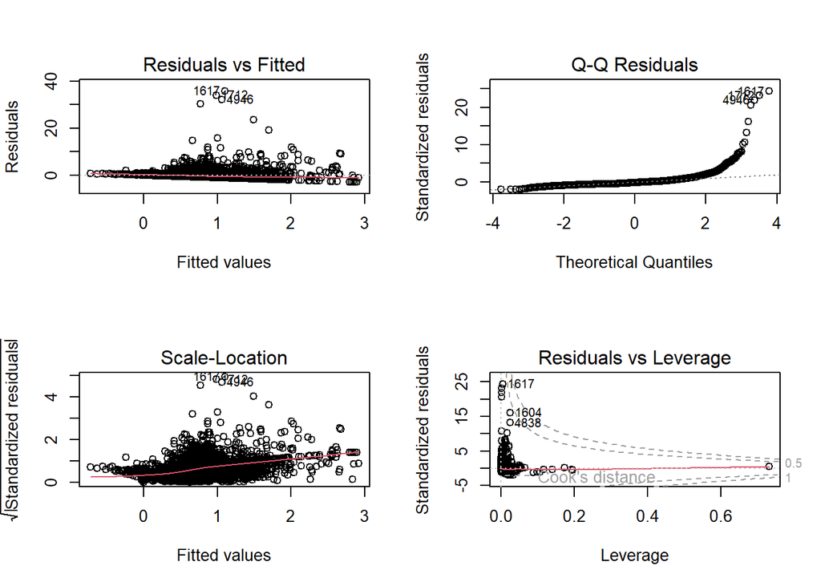

```r
par(mfrow = c(2, 2))  # Set up a 2x2 plot grid
plot(model_1)
```

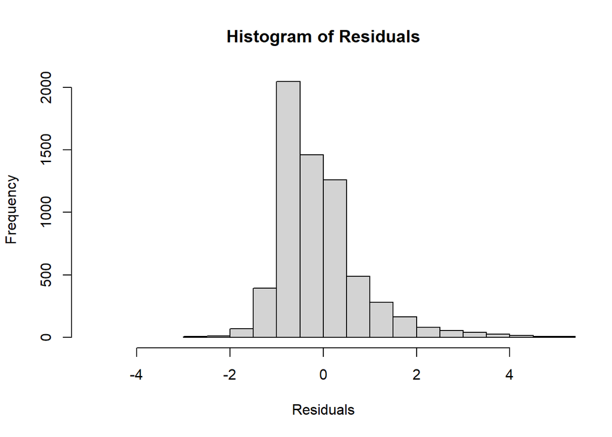

```r
residuals <- residuals(model_1)
hist(residuals,
     xlim=c(-5,5),
     breaks=100,
     main = "Histogram of Residuals", xlab = "Residuals")
```

## 5. Random Forest Regression

```r
# Hyperparameter tuning for random forest regression tree
# Define the tuning grid: include additional parameters
tuning_grid <- expand.grid(
  num.trees = c(100, 200, 300, 500),
  mtry = 1:(ncol(subset_data) - 1),
  splitrule = c("variance",'extratrees','maxstat'),    # Split rule for regression
  min.node.size = c(1, 5, 10),
  max.depth = c(0, 5, 10, 20)
)

# Randomly sample 60 combinations from the grid
set.seed(456)
random_combinations <- tuning_grid[sample(nrow(tuning_grid), 60), ]

# Cross-validation function
cross_validate <- function(data, formula, params, k = 5) {
  folds <- sample(1:k, nrow(data), replace = TRUE)
  scores <- numeric(k)

  for (i in 1:k) {
    # Split data into training and validation sets
    train_data <- data[folds != i, ]
    val_data <- data[folds == i, ]

    # Fit the model
    model <- ranger(
      formula = formula,
      data = train_data,
      splitrule = params$splitrule,
      num.trees = params$num.trees,
      mtry = params$mtry,
      min.node.size = params$min.node.size,
      max.depth = params$max.depth,
      num.threads=16
    )

    # Predict and calculate RMSE
    predictions <- predict(model, val_data)$predictions
    scores[i] <- sqrt(mean((val_data$Maternal_mortality_rate - predictions)^2))
  }

  # Return mean RMSE across folds
  mean(scores)
}

# Perform random search
results <- data.frame(random_combinations, RMSE = NA)

for (i in 1:nrow(random_combinations)) {
  if (i%%50==0)(
    cat(paste(".    ",i,"\r"))
  )
  else{
    cat(".")
  }
  params <- random_combinations[i, ]
  results$RMSE[i] <- cross_validate(
    data = subset_data,
    formula = Maternal_mortality_rate ~ .,
    params = params
  )
}
```

```
## ..................................................     50 ..........
```

Best Model from Hyperparameter Tuning

```r
# Find the best combination
best_model <- results[which.min(results$RMSE), ]
best_model
```

```
##      num.trees mtry splitrule min.node.size max.depth   RMSE
## 2517       100   21   maxstat             1        20 1.3184
```

### 5.2 Refit the final Random Forest model

```r
# Fit the Final Tree-Based Model
library(randomForest)
set.seed(123)
final_rf_model <- ranger(
  Maternal_mortality_rate ~ .,
  data = subset_data,
  num.trees = best_model$num.trees,
  splitrule = best_model$splitrule,
  mtry = best_model$mtry,
  min.node.size = best_model$min.node.size,
  max.depth = best_model$max.depth,
  num.threads=16,
  importance='permutation'
  )
```

```r
print(final_rf_model)
```

```
## Ranger result
##
## Call:
##  ranger(Maternal_mortality_rate ~ ., data = subset_data, num.trees = best_model$num.trees,      splitrule = best_model$splitrule, mtry = best_model$mtry,      min.node.size = best_model$min.node.size, max.depth = best_model$max.depth,      num.threads = 16, importance = "permutation")
##
## Type:                             Regression
## Number of trees:                  100
## Sample size:                      6461
## Number of independent variables:  21
## Mtry:                             21
## Target node size:                 1
## Variable importance mode:         permutation
## Splitrule:                        3
## OOB prediction error (MSE):       1.8793
## R squared (OOB):                  0.17854
```

### 5.3 Parameter Importance

```r
# Extract the importance metrics as a named vector
importance_metrics <- final_rf_model$variable.importance

# Convert to a data frame for easier manipulation
importance_df <- data.frame(
  Variable = names(importance_metrics),
  `%IncMSE` = importance_metrics
)

# Sort by `%IncMSE` in descending order
sorted_by_mse <- importance_df[order(-importance_df$`X.IncMSE`), ]

# View the sorted importance
print(sorted_by_mse)
```

```
##                                                                                          Variable
## Percent_pop_18_29                                                               Percent_pop_18_29
## Percent_pop_Black_and_African_American                     Percent_pop_Black_and_African_American
## Percent_pop_under_1.37_of_poverty_threshold           Percent_pop_under_1.37_of_poverty_threshold
## Median_household_income                                                   Median_household_income
## Percent_pop_American_Indian_and_Alaska_Native       Percent_pop_American_Indian_and_Alaska_Native
## Median_distance_to_nearest_obstetrics_department Median_distance_to_nearest_obstetrics_department
## Numer_of_health_centers                                                   Numer_of_health_centers
## Percent_pop_not_in_labor_force_16                               Percent_pop_not_in_labor_force_16
## Number_of_hospitals_with_emergency_department       Number_of_hospitals_with_emergency_department
## Percent_pop_Hispanic                                                         Percent_pop_Hispanic
## Number_of_hospitals_with_obstetric                             Number_of_hospitals_with_obstetric
## Percent_femal_pop                                                               Percent_femal_pop
## Percent_government_hospitals                                         Percent_government_hospitals
## Percent_pop_Native_Hawaiian_and_Pacific_Islander Percent_pop_Native_Hawaiian_and_Pacific_Islander
## Unemployment_rate_per_100_population_16                   Unemployment_rate_per_100_population_16
## Percent_pop_30_44                                                               Percent_pop_30_44
## Percent_pop_other_race                                                     Percent_pop_other_race
## Number_of_hospitals_with_ICU                                         Number_of_hospitals_with_ICU
## Percent_pop_Asian                                                               Percent_pop_Asian
## Percent_pop_15_17                                                               Percent_pop_15_17
## Number_of_midwives                                                             Number_of_midwives
##                                                    X.IncMSE
## Percent_pop_18_29                                 0.6091682
## Percent_pop_Black_and_African_American            0.2217020
## Percent_pop_under_1.37_of_poverty_threshold       0.1865136
## Median_household_income                           0.1852587
## Percent_pop_American_Indian_and_Alaska_Native     0.1656308
## Median_distance_to_nearest_obstetrics_department  0.1447556
## Numer_of_health_centers                           0.1248199
## Percent_pop_not_in_labor_force_16                 0.1088051
## Number_of_hospitals_with_emergency_department     0.0985811
## Percent_pop_Hispanic                              0.0758239
## Number_of_hospitals_with_obstetric                0.0715785
## Percent_femal_pop                                 0.0652898
## Percent_government_hospitals                      0.0410358
## Percent_pop_Native_Hawaiian_and_Pacific_Islander  0.0379512
## Unemployment_rate_per_100_population_16           0.0346045
## Percent_pop_30_44                                 0.0273442
## Percent_pop_other_race                            0.0256392
## Number_of_hospitals_with_ICU                      0.0239710
## Percent_pop_Asian                                -0.0093068
## Percent_pop_15_17                                -0.0385330
## Number_of_midwives                               -0.1527398
```

The column `%IncMSE` stands for percentage increase in Mean Squared Error. Measures how much the model’s prediction error increases when a particular variable is randomly permuted while keeping all other variables unchanged.. Higher values indicate that the variable is important for the model’s predictive accuracy.It reflects the variable’s contribution to the overall model performance.

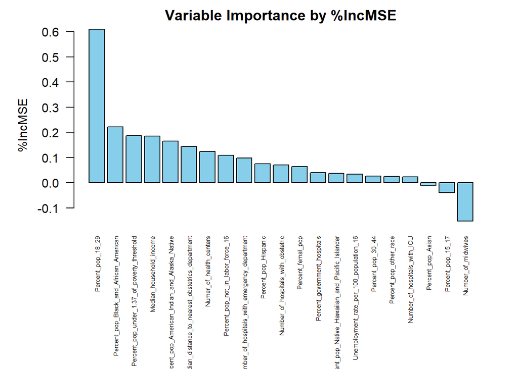

```r
# Adjust margins for longer labels
par(mar = c(10, 5, 2, 2))  # Increase bottom margin

# Bar plot with adjusted margins
barplot(sorted_by_mse[, "X.IncMSE"],
        names.arg = rownames(sorted_by_mse),
        las = 2,
        col = "skyblue",
        main = "Variable Importance by %IncMSE",
        ylab = "%IncMSE",
        cex.names = 0.5)
```

### 5.4 Partial Dependence of Key Features

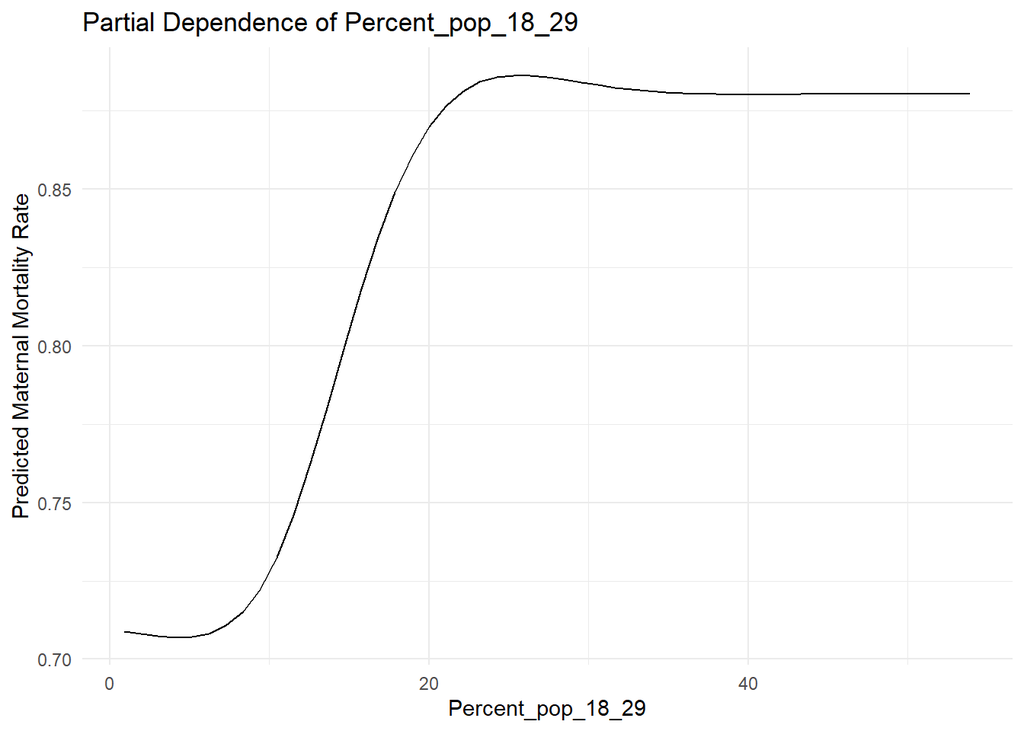

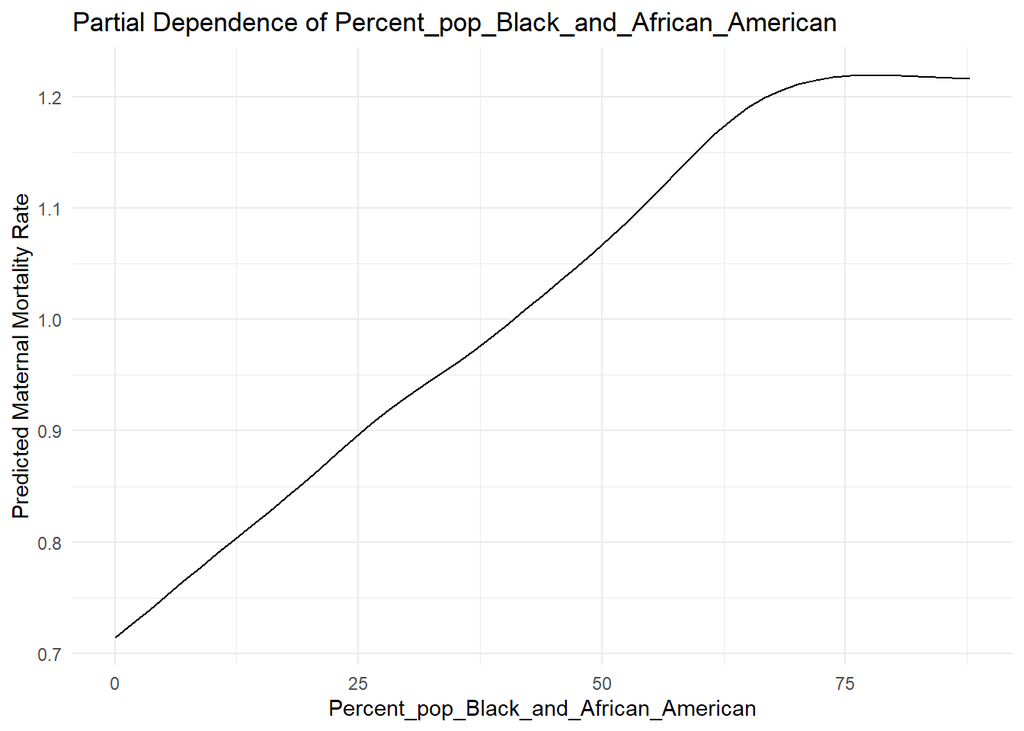

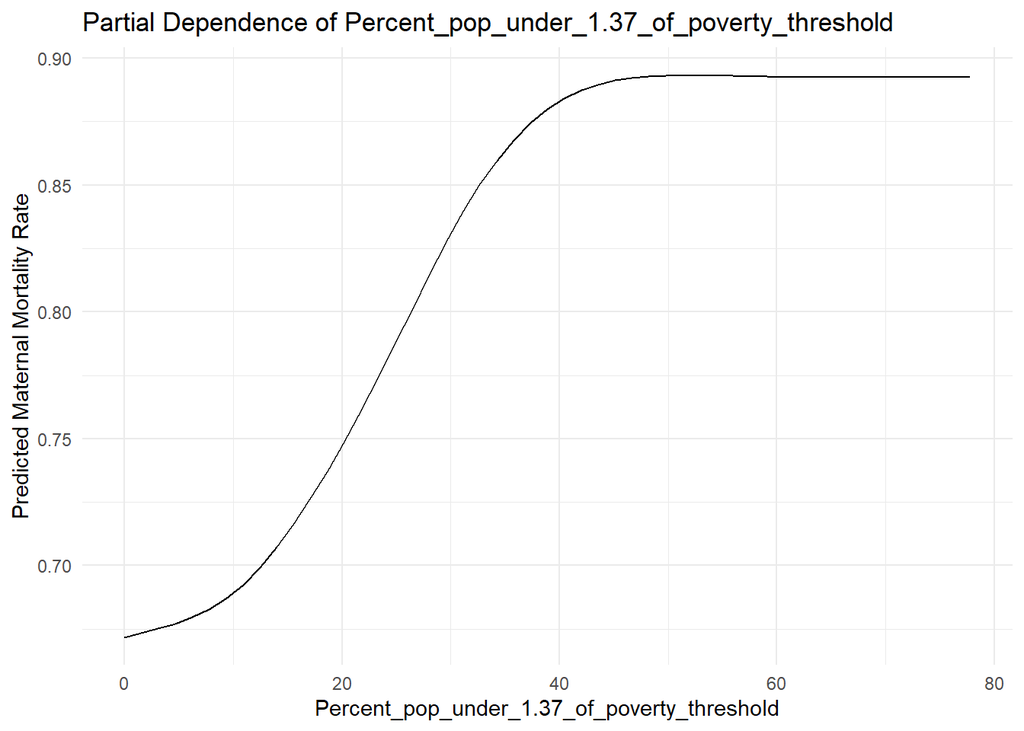

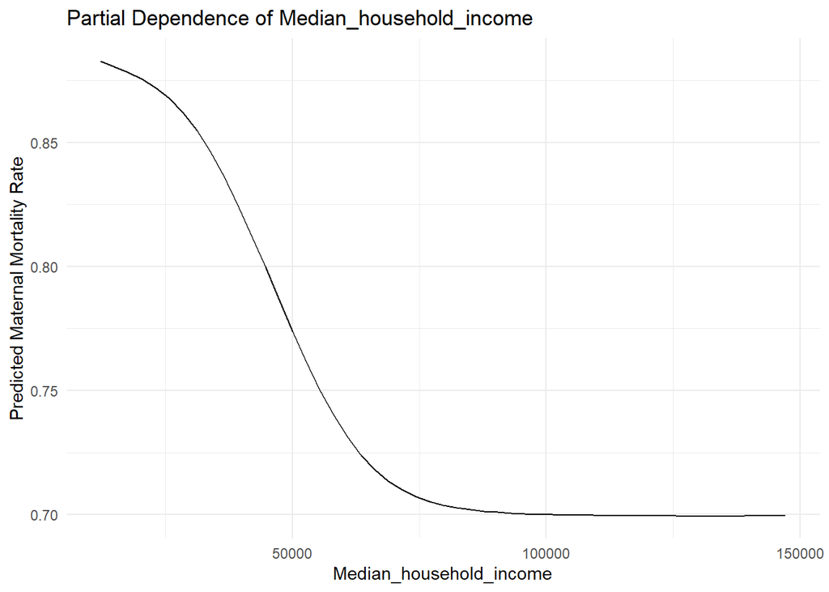

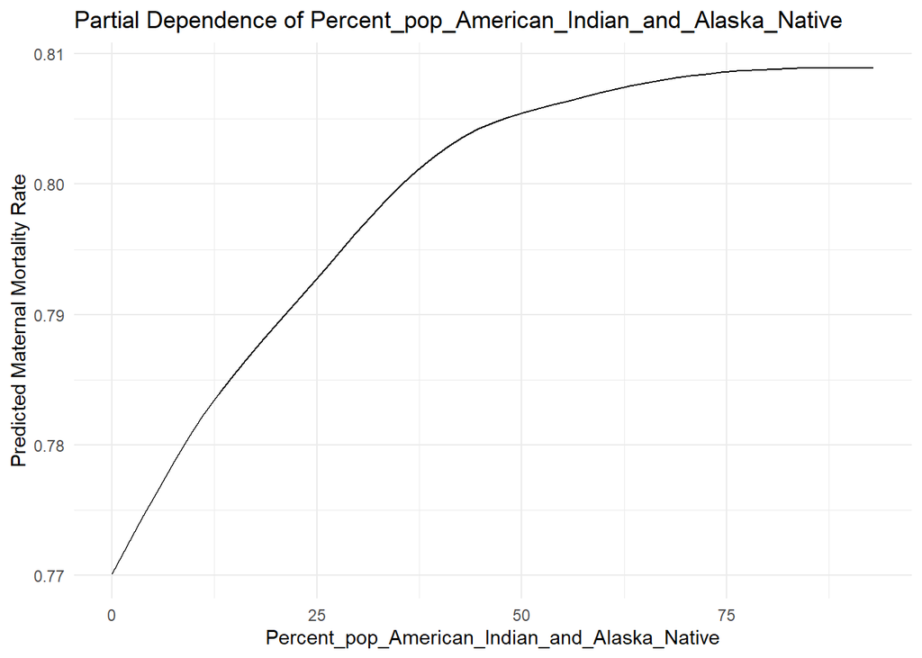

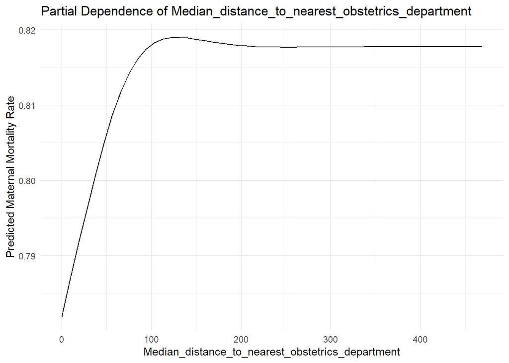

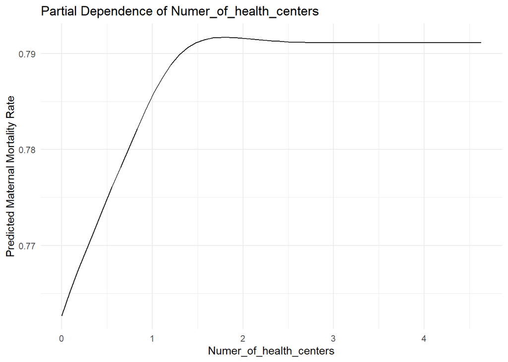

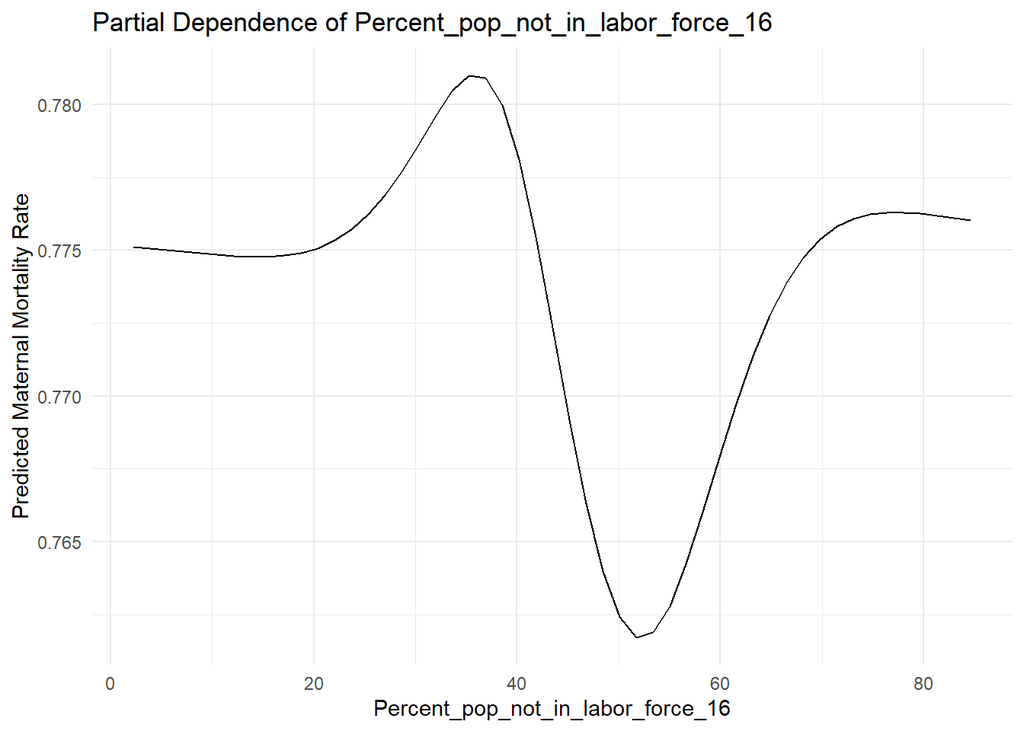

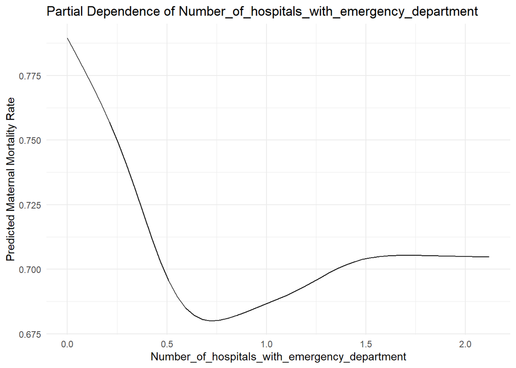

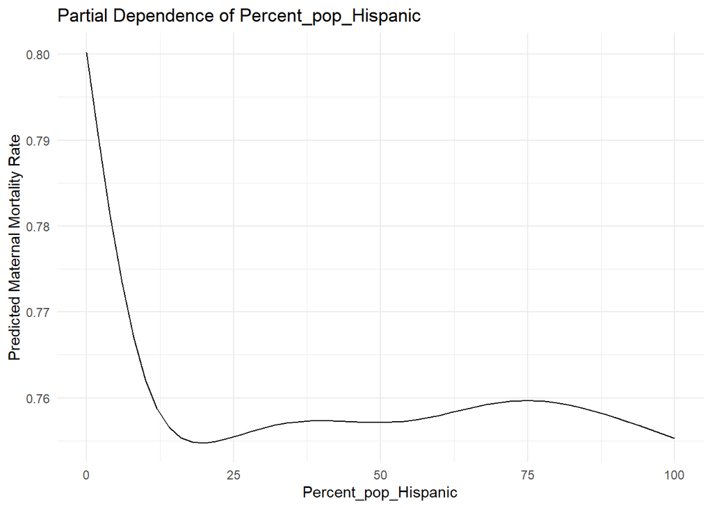

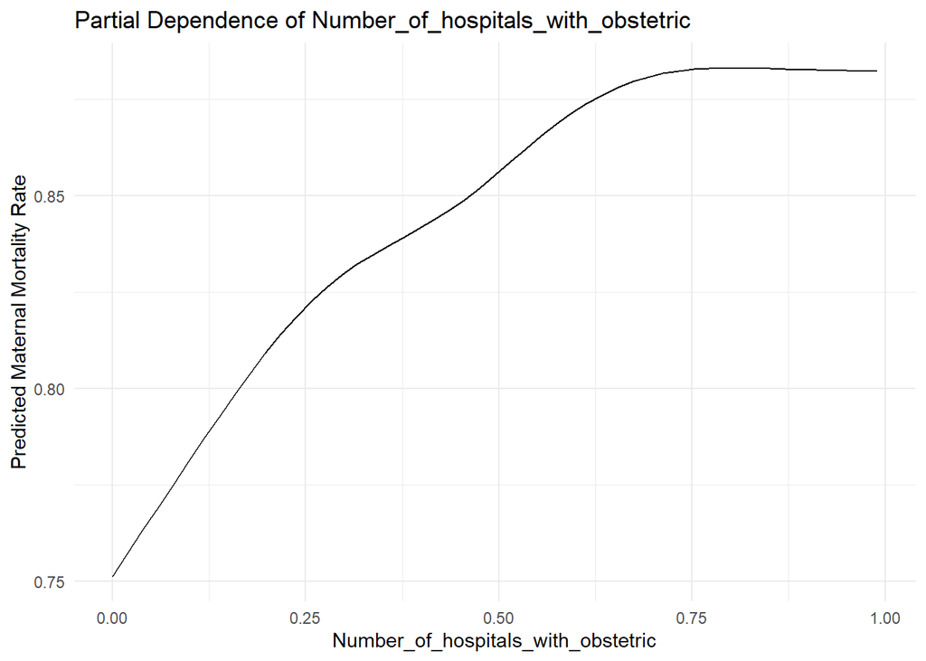

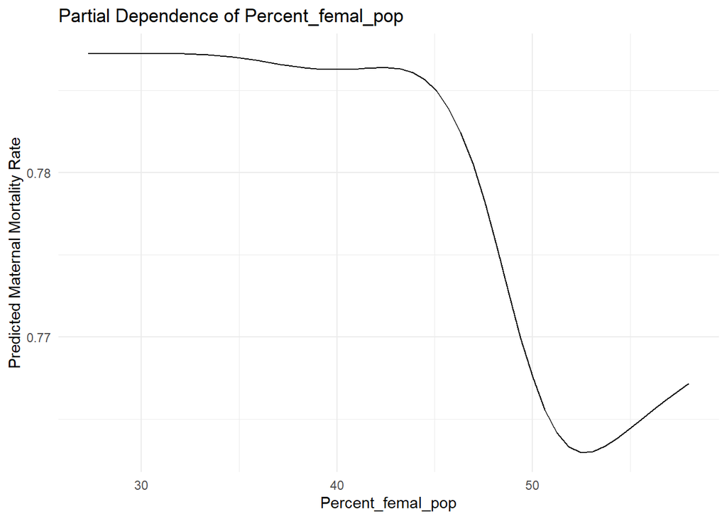

[9 more figures not shown]

```r
# Partial dependence for multiple features
features <- rownames(sorted_by_mse)

# Loop to generate and print plots

for (feature in features) {
  pd <- partial(
    object = final_rf_model,
    pred.var = feature,
    train = subset_data,
    pred.fun = function(object, newdata) {
      predict(object, data = newdata)$predictions
    }
  )

  # Convert partial dependence to a data frame
  pd_df <- as.data.frame(pd)
  # Apply spline smoothing
  spline_fit <- smooth.spline(pd_df[,feature], pd_df$yhat, spar = 0.7)  # spar = smoothing parameter

  # Convert spline results to a data frame for ggplot
  spline_df <- data.frame(
    feature = spline_fit$x,
    yhat_smooth = spline_fit$y
  )
  colnames(spline_df)[1] <- feature
  # Create a proper ggplot
  print(ggplot(spline_df, aes_string(x = feature, y = "yhat_smooth")) +
    geom_line() +
    ggtitle(paste("Partial Dependence of", feature)) +
    xlab(feature) +
    ylab("Predicted Maternal Mortality Rate") +
    theme_minimal())
}
```

The partial dependence plot for Median_distance_to_nearest_obstetrics_department shows an initial increase followed by a slight decrease as the Median_distance_to_nearest_obstetrics_department increases. This suggests that, in most counties, maternal mortality rates tend to rise with increasing distances to obstetrics departments, indicating that access to obstetric care is a critical factor. However, in rural counties, where the Median_distance_to_nearest_obstetrics_department is typically higher, the population density is lower, resulting in fewer pregnancies and, consequently, a lower maternal mortality rate despite the greater distances.

Socioeconomic Factors

The coefficients for Percent_pop_Black_and_African_American and Percent_pop_American_Indian_and_Alaska_Native are positive and significant, indicating that a higher percentage of these racial populations is associated with increased maternal mortality. This highlights the impact of systemic inequities and potential disparities in healthcare access.

Solutions: Improve Healthcare Access: Expand healthcare services in minority-dense areas to reduce disparities. Culturally Tailored Programs: Implement maternal health programs designed to meet the unique needs of these communities. Provider Training: Invest in training healthcare providers to ensure culturally competent and bias-free care.

Solutions: Policy Support for Young Mothers: Introduce affordable childcare, flexible work arrangements, and extended parental leave policies to support younger women starting families. Education and Awareness: Raise awareness about the risks of delayed childbearing and provide tailored prenatal care for older mothers.

Healthcare Access

The coefficient for `Number_of_hospitals_with_ICU` is negatively significant, indicating that a greater number of hospitals with ICU facilities is associated with lower maternal mortality rates. This underscores the importance of ICU availability in reducing severe maternal outcomes.

Solutions: Expand ICU Facilities: Increase the number of hospitals with ICU care, especially in underserved and rural areas. Upgrade Healthcare Infrastructure: Build or modernize healthcare facilities to ensure ICU services are available in high-risk regions.

Economic Disparities The coefficient for `Median_household_income` is negative and significant, suggesting that counties with higher income levels tend to have lower maternal mortality rates. This highlights the influence of socioeconomic conditions on maternal health outcomes.

Solutions: Support Low-Income Populations: Strengthen socioeconomic support systems for low-income communities through targeted interventions. Healthcare Subsidies: Expand access to healthcare subsidies, prenatal care programs, and financial assistance for underserved populations. Workforce Development: Implement programs to promote economic stability and job opportunities in high-risk counties.